# Análise Inteligente dos Dados (Yuri AT)

### Introdução

A cronificação da hepatite C (HCV) é considerada um problema de saúde pública. Logo, sendo o principal objetivo do tratamento erradicar o HCV e melhorar a qualidade de vida dos pacientes, o monitoramento do horizonte do tratamento é de suma importância. Assim sendo, em 2015, no Sistema Único de Saúde (SUS) foram liberados os fármacos sofosbuvir, daclatasvir e simeprevir para tratamento da Hepatite C dos genótipos 1, 2, 3 e 4 com fibrose avançada e de coinfectados pelo HIV-1. Sendo o regime terapêutico mais recomendado, a combinação dos fármacos sofosbuvir+simeprevir ou sofosbuvir+daclatasvir.

####Objetivo O objetivo dessa análise é comparar o impacto da inserção da dispensação de novos medicamentos para o tratamento do HCV nu SUS. As novas recomendaçõe implicam em maior dispensação dos medicamentos daclastavir, simeprevir e sofosbuvir segundo o regime terapêutico. Com isso queremos verificar primeiramente **se o protocolo recomendando está sendo seguido**. E então o quanto o perfil da dispensação total desses medicamentos varia em cada estado no período de impletação (entre janeiro de 2016 e dezembro de 2017). Com o interesse final de estimar dentre o perfil observado quais podem vir a ser as variáveis secundárias mais explicativas para a mortalidade estadual do HCV e qual modelo preditivo pode ser aplicado dado as variáveis secundárias.

####Descrição dos dados Os dados aqui analisados foram obtidos pela plataforma online de livre acesso do DATASUS (http://tabnet.datasus.gov.br) e exportados em diferentes tabelas contendo a quantidade apresentada por local de atendimento na produção ambulatorial do sus para a combinação de fármacos recomendados no tratamento da hepatite C. Que são eles o daclastavir (60 mg), sofosbuvir (60 mg) e simeprevir (150 mg). As colunas de cada tabela foram subdivididas pelo ano de registro e cada linha corresponde a frequência apresentada por unidade de federação. Também foram incluidos dados referentes ao IDH e a infraestrutura para dispensação de fármacos de cada unidade de federação todos relativizados pela população total de cada estado ou pela população de incidência em dois conjuntos de dados diferentes (um parao ano de 2016 e outro para o ano de 2017).

#####Variáveis

**Taxa = variável controlada (dividida) pela potencial população de risco para HCV- [1% do estado]**

1. uf = sigla referente aos estados (char-fator)
2. regiao = sigla referente as regiões (char-fator)
3. obitos16pc = *Logarítimo na base 10* do coeficiente de mortalidade por HCV, por 100.000 habitantes (p/ maior normalização)
4. incidencia16p = Coeficiente de detecção por 100.000 habitantes de casos com marcador anti-HCV reagente e HCV-RNA reagente
5. dacl_2016 = **Taxa** da dispensação de comprimidos do medicamento daclastavir (60 mg)
6. sulfo_2016 = **Taxa** da dispensação de comprimidos do medicamento sofosbuvir (60 mg)
7. sime_2016 = **Taxa** da dispensação de comprimidos do medicamento simeprevir (150 mg)
8. dispensa16p = **Taxa** da dispensação total de comprimidos dos três medicamento
9. farmacia16p = **Taxa** de estabelecimentos de saúde (na PNAF) em que é feita a dispensação de medicamentos excepcionais
10. ensino16 = **Taxa** de centros médicos com atividade de ensino
11. infraestrutura16p = **Taxa** do quantitativo geral de estabelecimentos de saúde contidos no CNES
12. habilita16 = Estabelecimentos de saúde hablitados a realizar a detecção por marcador anti-HCV reagente e HCV-RNA reagente
13. IDHM_renda = Índice de Desenvolvimento Humano Municipal de Renda (2010)
14. IDHM_logevidade = Índice de Desenvolvimento Humano Municipal de Longevidade (2010)
15. IDHM_educacao = Índice de Desenvolvimento Humano Municipal de Educação (2010)
16. gini = Índice de desigualdade estadual em 2010
17. obitos16p = Coeficiente de mortalidade por HCV, por 100.000 habitantes

###Análise descritiva para protocolo de distribuição dos fármacos

#####Representações por mapas de árvore (treemap)

Nossa primeira hipótese foi de que a adesão ao protocolo recomendado para dispensação dos medicamentos fosse diferente entre os estados e regiões, dentre os anos de 2016 e 2017. Dado a possíveis problemas de registro ou da própria infraestrutura e demanda de cada estado. Assim sendo, para melhor visualizarmos a distribuição das variáveis perante o protocolo da dispensação dos medicamentos usamos o *treemap* como uma representação hierárquica da dispensação dos três diferentes medicamentos primeiramente pelas regiões, então pelos anos e for fim **categorizadas por cada estado** subdividido em regiões e ano.

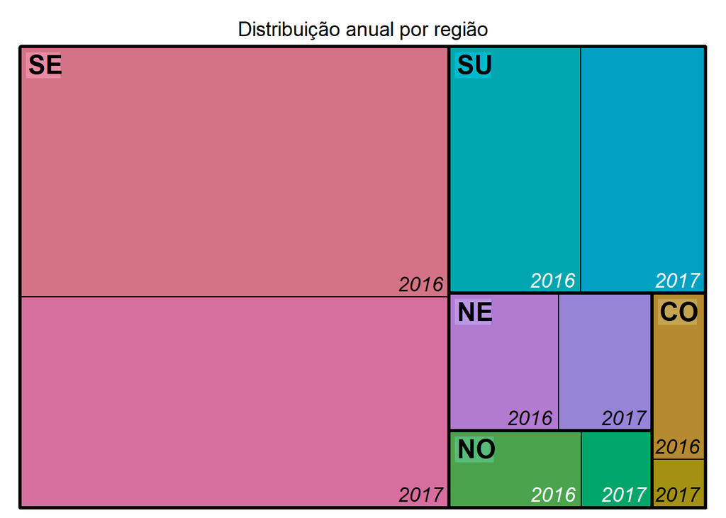

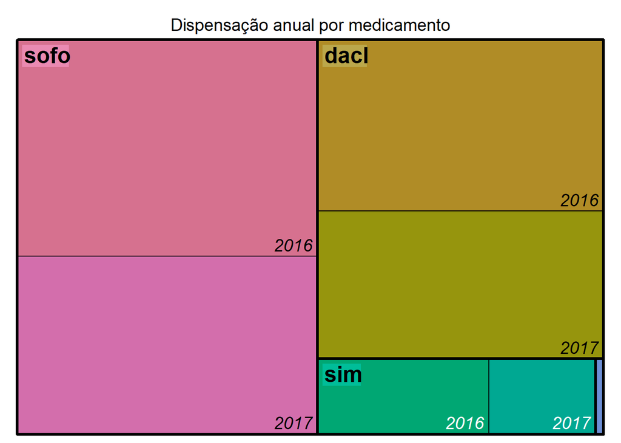

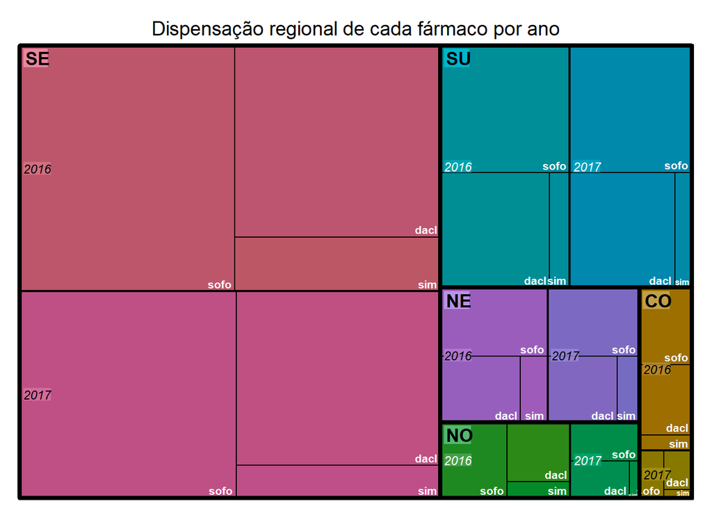

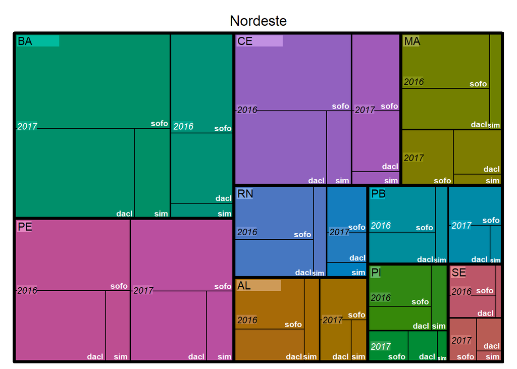

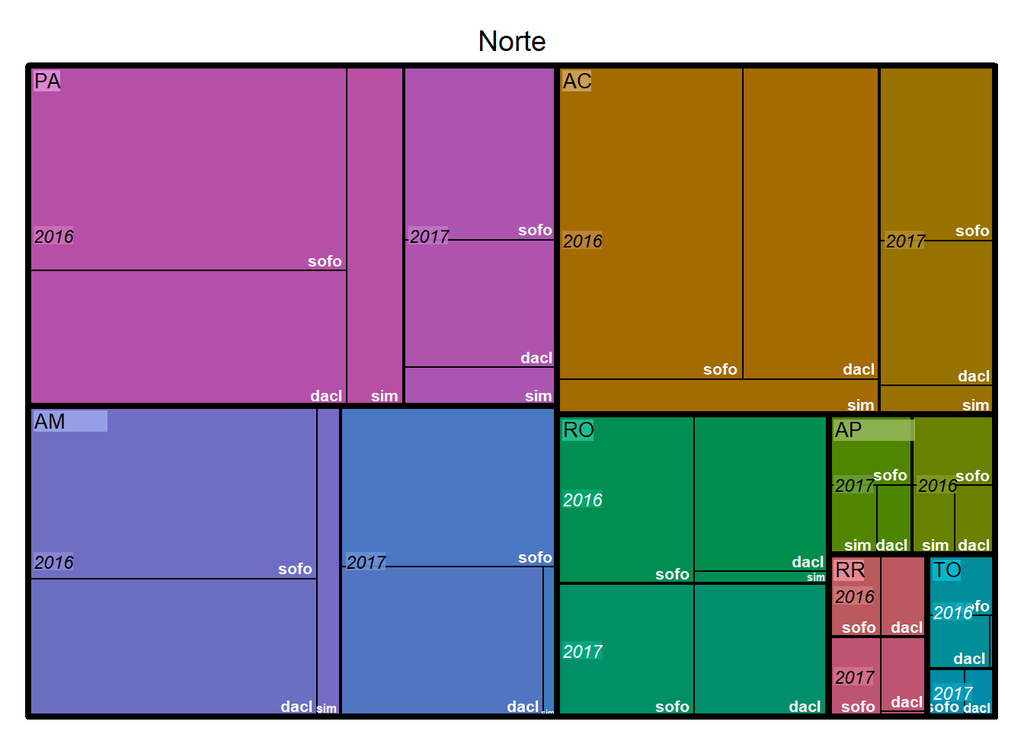

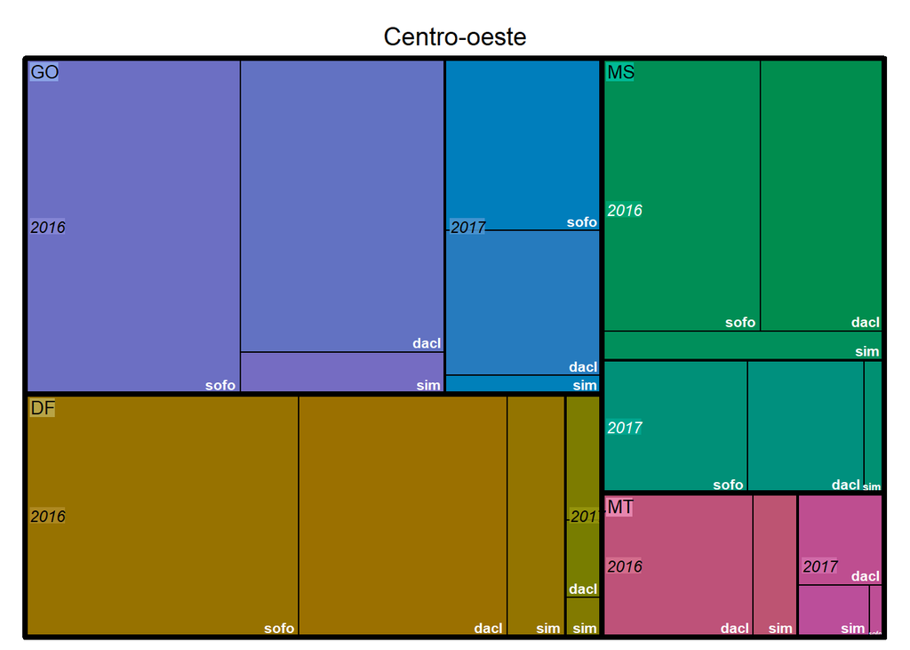

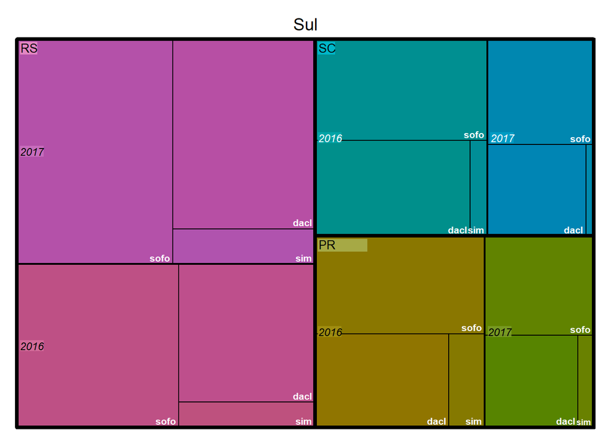

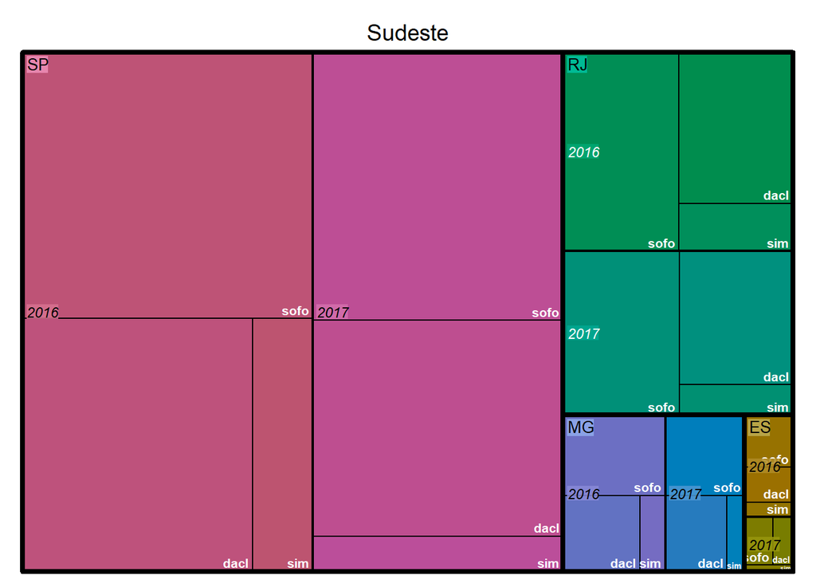

No gráfico de barras apresentado abaixo a tendência de menor dispensação em 2017 é reforçada, mesmo com a inserção de um novo protocolo de tratamento (combinação 3D liderada por ombitasvir) não influenciando a proporção do protocolo recomendado anteriormente.

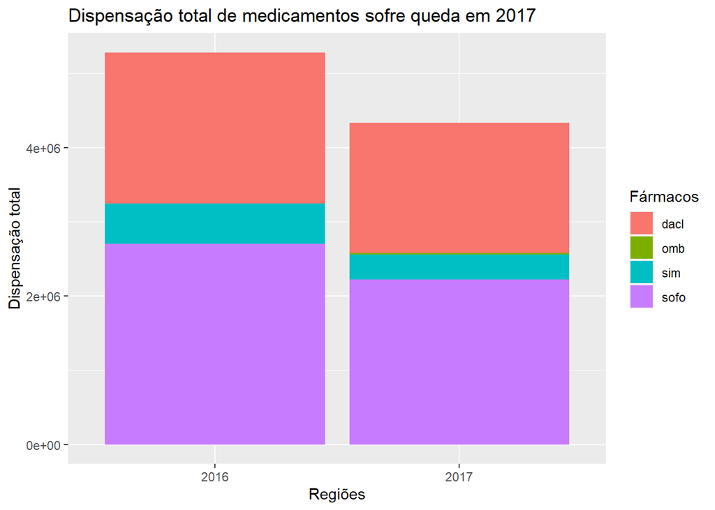

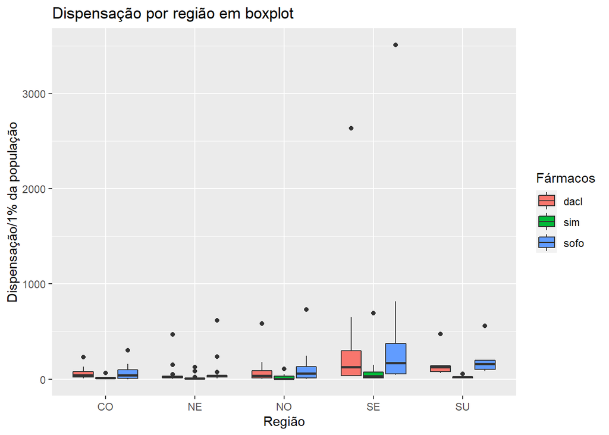

O boxplot acima demonstra a influência do outlier na região sudeste para a taxa de dispensação, mesmo essa sendo controlada pela população estadual. Apesar dessa distorção, pelo boxplot podemos observar que as demais regiões possuem média similares e menor impacto de seus outliers, seguindo o protocolo de forma correlacionado

#####Correlação entre a taxa de dispensação dos diferentes medicamentos

```r
cor(hcvdata16[,c(3:5)])
```

```
##             dacl_2016p sulfo_2016p sime_2016p
## dacl_2016p   1.0000000   0.9994777  0.9887918
## sulfo_2016p  0.9994777   1.0000000  0.9922338
## sime_2016p   0.9887918   0.9922338  1.0000000
```

#####Considerações iniciais

A própria correlação entre as dispensações dos diferentes medicamentos, indica que o protocolo recomendado para a dispensação está sendo seguido. Assim sendo, podemos concluir que, de maneira geral a dispensação entre os diferentes medicamentos é padronizada entre os estados sendo mais interessante agregarmos em uma *dispensação total* para a modelagem.

###Análise descritiva para o índice de mortalidade

Logo, precisamos então verificar como as demais variáveis explanatórias estão distribuidas. Para tal iremos usar a função **summary** e a *correlação* entre essas variáveis, dado que através delas podemos ter uma visualização primária de quais varíaveis apresentam maior correlação com a taxa de mortalidade, variável de saída que almejamos compreender e predizer. Para a variável de interesse (mortalidade) precisamos verificar que tipo de distribuição está sendo seguida, para melhor entender qual modelo melhor se aplica ao caso. Para tal iremos usar o histograma e consequentes testes para uma distribuição normal (dado que temos a mortalidade de 27 estados)

```r
#Resumo dos dados de 2016
summary(hcvdata16)
```

```
##       uf16    regiao16   dacl_2016p        sulfo_2016p        sime_2016p
##  AC     : 1   CO:4     Min.   :   2.539   Min.   :   0.00   Min.   :  0.000
##  AL     : 1   NE:9     1st Qu.:  20.815   1st Qu.:  23.16   1st Qu.:  5.857
##  AM     : 1   NO:7     Median :  59.161   Median :  75.62   Median : 18.741
##  AP     : 1   SE:4     Mean   : 212.383   Mean   : 279.20   Mean   : 54.471
##  BA     : 1   SU:3     3rd Qu.: 151.477   3rd Qu.: 221.66   3rd Qu.: 48.524
##  CE     : 1            Max.   :2635.568   Max.   :3510.39   Max.   :692.693
##  (Other):21
##    obitos16pc       incidencia16p     dispensa16p        farmacia16p
##  Min.   :-0.52288   Min.   : 0.300   Min.   :   5.417   Min.   :0.002658
##  1st Qu.:-0.39794   1st Qu.: 1.300   1st Qu.:  53.346   1st Qu.:0.031555
##  Median :-0.22185   Median : 2.600   Median : 149.204   Median :0.077511
##  Mean   :-0.18469   Mean   : 4.215   Mean   : 546.053   Mean   :0.224771
##  3rd Qu.:-0.02288   3rd Qu.: 4.050   3rd Qu.: 439.095   3rd Qu.:0.260317
##  Max.   : 0.53148   Max.   :22.500   Max.   :6838.647   Max.   :1.393336
##
##    ensino16p       infraestrutura16p    habilita16      IDHM_renda16
##  Min.   :0.00443   Min.   :  0.5201   Min.   : 0.000   Min.   :0.6120
##  1st Qu.:0.06995   1st Qu.:  5.3859   1st Qu.: 1.000   1st Qu.:0.6670
##  Median :0.18810   Median : 14.9530   Median : 1.000   Median :0.6940
##  Mean   :0.38349   Mean   : 29.0603   Mean   : 1.926   Mean   :0.7069
##  3rd Qu.:0.41502   3rd Qu.: 30.3133   3rd Qu.: 2.000   3rd Qu.:0.7425
##  Max.   :2.22657   Max.   :218.2645   Max.   :11.000   Max.   :0.8630
##
##  IDHM_logevidade16 IDHM_educacao16      gini16         obitos16p
##  Min.   :0.7550    Min.   :0.5200   Min.   :0.4900   Min.   :0.0000
##  1st Qu.:0.7860    1st Qu.:0.5605   1st Qu.:0.5600   1st Qu.:0.3500
##  Median :0.8050    Median :0.6240   Median :0.6000   Median :0.5000
##  Mean   :0.8086    Mean   :0.6124   Mean   :0.5907   Mean   :0.7741
##  3rd Qu.:0.8340    3rd Qu.:0.6440   3rd Qu.:0.6200   3rd Qu.:0.8000
##  Max.   :0.8730    Max.   :0.7420   Max.   :0.6500   Max.   :3.4000
##
```

#####Verificando distribuição do índice de mortalidade controlado X não controlado.

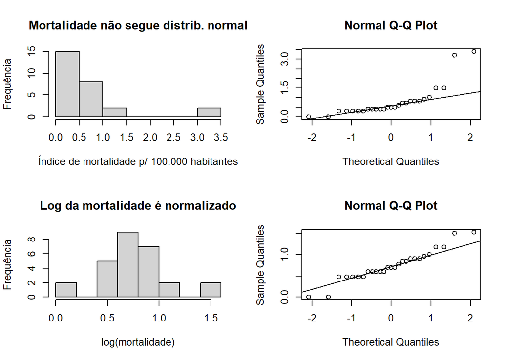

```
##
##  Shapiro-Wilk normality test
##
## data:  hcvdata16$obitos16p
## W = 0.68457, p-value = 2.383e-06
```

```
##
##  Shapiro-Wilk normality test
##
## data:  log_hcvdata16$obitos16p
## W = 0.94527, p-value = 0.1643
```

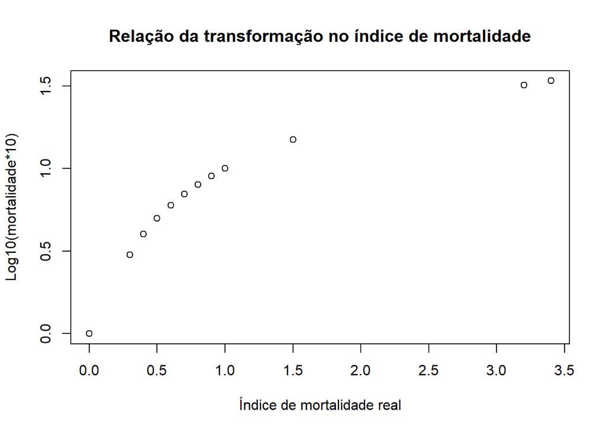

Pelos gráficos e pelo resultado do Shapiro-test no índice de mortalidade transformado (p > 0.05), podemos observar que o índice de mortalidade passa a seguir uma distribuição normal. A transformação aqui utilizada foi a aplicação do logarítimo na base 10 do índice de mortalidade multiplicado por 10, de forma a manter a escala positiva e reduzir o impacto dos valores extremos que já eram esperados na distribuição devido ao perfil díspare de alguns estados. A mesma transformação foi aplicada nas demais variáveis numéricas, visto que todas sofrem as mesmas influências estaduais, com isso podemos melhor verificar a correlação presente entre as variáveis

#####Correlação por cores e tamanho dentre as variáveis numéricas

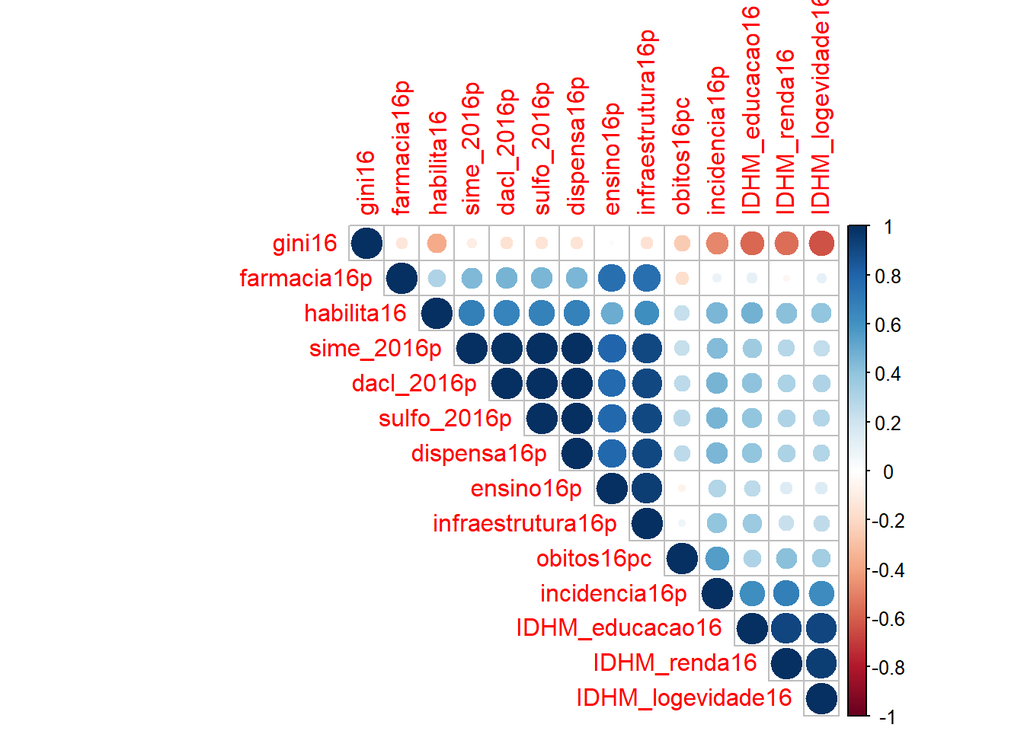

```r
x <- cor(hcvdata16[3:16])
corrplot(x, type="upper", order="hclust")
```

#####Distruibuição e correlação entre as variáveis que parecem mais interligadas à mortalidade

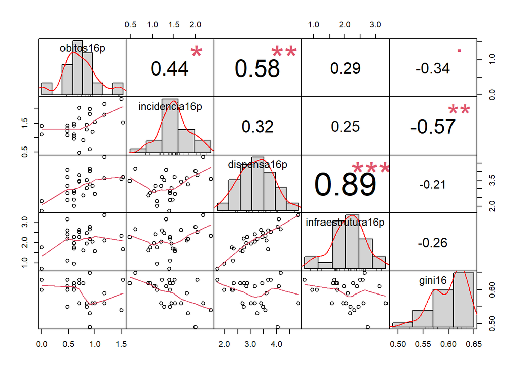

```r
#Gráfico de distruibuição e correlação entre as variáveis que parecem estar mais interligadas ao ínidice de mortalidade
chart.Correlation(subset(log_hcvdata16, select = c(obitos16p,incidencia16p,dispensa16p,infraestrutura16p,gini16)))
```

####Análise dos outliers

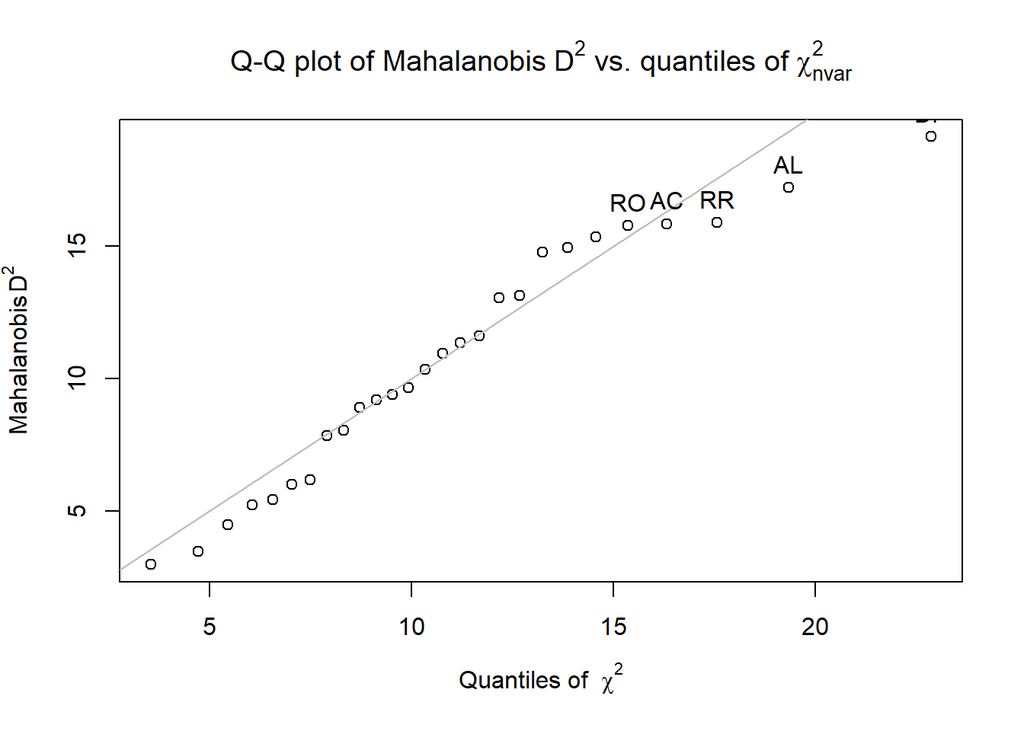

```
##        RO        AC        AM        RR        PA        AP        TO        MA
## 15.779496 15.842049 11.589838 15.886545  9.645849  7.836514 10.326232  8.906016
##        PI        CE        RN        PB        PE        AL        SE        BA
## 15.328480 13.037268  5.421475  3.467773  5.216831 17.207482 10.953837  8.025212
##        MG        ES        RJ        SP        PR        SC        RS        MS
## 11.333967  2.972366  6.007608 14.771877  9.401879 14.945491 13.140841  4.476583
##        MT        GO        DF
##  9.187514  6.166817 19.124162
```

Por esse gráfico podemos observar que os estados que mais se distanciam do centro são Rondônia, Roraima, Acre, Alagoas e o Distrito Federal, o que é de certa forma coerente com o observado anteriormente nos *treemaps*. Além de demonstrar que a tranformação das variáveis diminuiu o impacto dos estados do Rio de Janeiro e São Paulo. O que se torna ainda mais evidente no scatterplot abaixo que com a **remoção dos outliers**, inclui a dispensação pela infraestrura crescente de forma aproximadamente linear dentre todas as regiões e uma tendência a maiores índices de mortalidade com o aumento da dispensação, podendo essa estar indicando a gravidade do HCV por localidade.

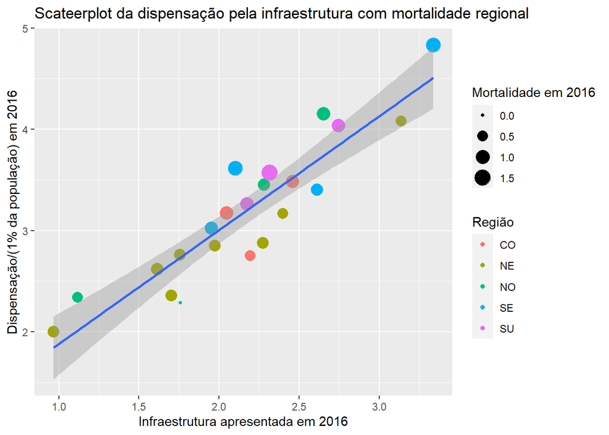

####Definindo os conjuntos de treinamento e teste

```r
#----Grupos de treinamento (banco de 2016) e teste (banco de 2017)
ta16 <- rl16
te17 <- rl17
dim(ta16)
```

```
## [1] 27 12
```

```r
dim(te17)
```

```
## [1] 27 12
```

```r
#------Grupos de treinamento (70%) e teste (30%)
set.seed(314)
indexes <- sample (1:nrow(rl16), size=.3*nrow(rl16))
hcv16test <- rl16[indexes,]
hcv16train <- rl16[-indexes,]
dim(hcv16test)
```

```
## [1]  8 12
```

```r
dim(hcv16train)
```

```
## [1] 19 12
```

####Modelo linear com banco de dados de 2016 completo

```r
modelo0 = lm(rl16$obitos16p ~., data=rl16)
summary(modelo0)
```

```
##
## Call:
## lm(formula = rl16$obitos16p ~ ., data = rl16)
##
## Residuals:
##      Min       1Q   Median       3Q      Max
## -0.41250 -0.03853  0.01818  0.07500  0.23192
##
## Coefficients:
##                   Estimate Std. Error t value Pr(>|t|)
## (Intercept)        1.63792    3.17534   0.516 0.615348
## regiao16NE        -0.06733    0.28697  -0.235 0.818449
## regiao16NO        -0.26448    0.28024  -0.944 0.363906
## regiao16SE        -0.01896    0.20005  -0.095 0.926048
## regiao16SU        -0.04751    0.23374  -0.203 0.842345
## incidencia16p      0.17538    0.18986   0.924 0.373822
## dispensa16p        0.81044    0.14876   5.448 0.000148 ***
## farmacia16p        0.06838    0.18898   0.362 0.723755
## ensino16p         -0.07987    0.23794  -0.336 0.742924
## infraestrutura16p -0.79358    0.46425  -1.709 0.113088
## habilita16         0.01552    0.02354   0.660 0.521974
## IDHM_renda16       3.43180    3.19347   1.075 0.303673
## IDHM_logevidade16  0.86894    5.86390   0.148 0.884658
## IDHM_educacao16   -6.06292    2.07891  -2.916 0.012927 *
## gini16            -2.32947    2.68590  -0.867 0.402790
## ---
## Signif. codes:  0 '***' 0.001 '**' 0.01 '*' 0.05 '.' 0.1 ' ' 1
##
## Residual standard error: 0.1904 on 12 degrees of freedom
## Multiple R-squared:  0.8701, Adjusted R-squared:  0.7186
## F-statistic: 5.743 on 14 and 12 DF,  p-value: 0.002194
```

```r
#ANOVA do modelo
anova(modelo0)
```

```
## Analysis of Variance Table
##
## Response: rl16$obitos16p
##                   Df  Sum Sq Mean Sq F value    Pr(>F)
## regiao16           4 0.89293 0.22323  6.1578 0.0062220 **
## incidencia16p      1 0.03498 0.03498  0.9650 0.3453263
## dispensa16p        1 0.52804 0.52804 14.5658 0.0024550 **
## farmacia16p        1 0.10633 0.10633  2.9331 0.1124763
## ensino16p          1 0.69434 0.69434 19.1532 0.0009019 ***
## infraestrutura16p  1 0.24786 0.24786  6.8371 0.0226011 *
## habilita16         1 0.00201 0.00201  0.0555 0.8176790
## IDHM_renda16       1 0.00507 0.00507  0.1399 0.7148902
## IDHM_logevidade16  1 0.09292 0.09292  2.5632 0.1353615
## IDHM_educacao16    1 0.28320 0.28320  7.8119 0.0161943 *
## gini16             1 0.02727 0.02727  0.7522 0.4027899
## Residuals         12 0.43502 0.03625
## ---
## Signif. codes:  0 '***' 0.001 '**' 0.01 '*' 0.05 '.' 0.1 ' ' 1
```

```r
## Importância das variáveis
varImp(modelo0)
```

```
##                      Overall
## regiao16NE        0.23463313
## regiao16NO        0.94376149
## regiao16SE        0.09478712
## regiao16SU        0.20325020
## incidencia16p     0.92374369
## dispensa16p       5.44785181
## farmacia16p       0.36185081
## ensino16p         0.33565817
## infraestrutura16p 1.70939001
## habilita16        0.65959048
## IDHM_renda16      1.07463102
## IDHM_logevidade16 0.14818417
## IDHM_educacao16   2.91639175
## gini16            0.86729635
```

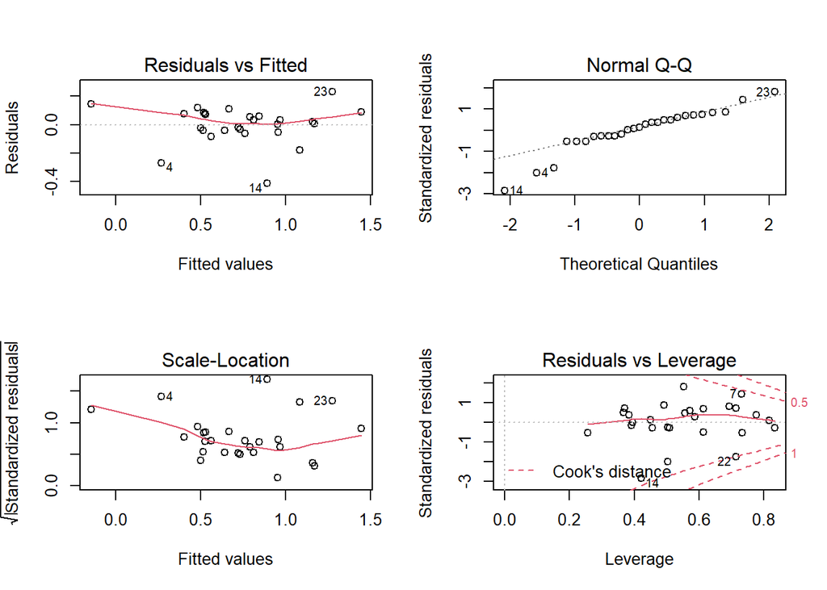

```r
par(mfrow=c(2,2))
plot(modelo0)
```

####Modelo linear subdividindo o mesmo grupo

```r
modelo1 = lm(hcv16train$obitos16p ~., data=hcv16train)
summary(modelo1)
```

```
##
## Call:
## lm(formula = hcv16train$obitos16p ~ ., data = hcv16train)
##
## Residuals:
##         1         4         5         6         8         9        10        11
## -0.008229 -0.094096  0.009021  0.093304 -0.030012 -0.024575  0.047798  0.028442
##        15        16        17        18        19        21        22        23
##  0.016775 -0.038427 -0.021478  0.079986 -0.058508  0.038099 -0.091003  0.052904
##        24        25        27
## -0.015431  0.004746  0.010684
##
## Coefficients:
##                    Estimate Std. Error t value Pr(>|t|)
## (Intercept)        4.264978   3.161578   1.349  0.24864
## regiao16NE        -0.315370   0.211626  -1.490  0.21042
## regiao16NO        -0.610498   0.230858  -2.644  0.05731 .
## regiao16SE        -0.084885   0.146500  -0.579  0.59337
## regiao16SU        -0.095335   0.276113  -0.345  0.74728
## incidencia16p      0.411738   0.194013   2.122  0.10109
## dispensa16p        1.028981   0.212715   4.837  0.00842 **
## farmacia16p        0.145407   0.173012   0.840  0.44796
## ensino16p          0.033919   0.229386   0.148  0.88960
## infraestrutura16p -1.176602   0.381709  -3.082  0.03684 *
## habilita16         0.003402   0.021096   0.161  0.87970
## IDHM_renda16       3.278035   2.298153   1.426  0.22691
## IDHM_logevidade16 -1.621433   4.983451  -0.325  0.76121
## IDHM_educacao16   -8.174394   1.508718  -5.418  0.00562 **
## gini16            -1.008612   2.522086  -0.400  0.70966
## ---
## Signif. codes:  0 '***' 0.001 '**' 0.01 '*' 0.05 '.' 0.1 ' ' 1
##
## Residual standard error: 0.1087 on 4 degrees of freedom
## Multiple R-squared:  0.9738, Adjusted R-squared:  0.8822
## F-statistic: 10.63 on 14 and 4 DF,  p-value: 0.01727
```

```r
#ANOVA do modelo
anova(modelo1)
```

```
## Analysis of Variance Table
##
## Response: hcv16train$obitos16p
##                   Df  Sum Sq Mean Sq F value   Pr(>F)
## regiao16           4 0.78503 0.19626 16.6130 0.009305 **
## incidencia16p      1 0.00312 0.00312  0.2637 0.634636
## dispensa16p        1 0.08606 0.08606  7.2850 0.054147 .
## farmacia16p        1 0.00276 0.00276  0.2337 0.654097
## ensino16p          1 0.02746 0.02746  2.3244 0.202044
## infraestrutura16p  1 0.22654 0.22654 19.1761 0.011884 *
## habilita16         1 0.00429 0.00429  0.3634 0.579154
## IDHM_renda16       1 0.00143 0.00143  0.1213 0.745182
## IDHM_logevidade16  1 0.26273 0.26273 22.2400 0.009199 **
## IDHM_educacao16    1 0.35701 0.35701 30.2206 0.005337 **
## gini16             1 0.00189 0.00189  0.1599 0.709657
## Residuals          4 0.04725 0.01181
## ---
## Signif. codes:  0 '***' 0.001 '**' 0.01 '*' 0.05 '.' 0.1 ' ' 1
```

```r
## Importância das variáveis
varImp(modelo1)
```

```
##                     Overall
## regiao16NE        1.4902190
## regiao16NO        2.6444774
## regiao16SE        0.5794176
## regiao16SU        0.3452765
## incidencia16p     2.1222146
## dispensa16p       4.8373629
## farmacia16p       0.8404479
## ensino16p         0.1478680
## infraestrutura16p 3.0824595
## habilita16        0.1612624
## IDHM_renda16      1.4263780
## IDHM_logevidade16 0.3253634
## IDHM_educacao16   5.4181068
## gini16            0.3999116
```